# Simplest General Equilibrium in Python

We consider a static, competitive economy with a representative household and firm, one produced good, labor $L$, and capital $K$. The price of the good is $P$ (we set $P=1$ as numeraire in equilibrium), the real wage is $w$, and the rental rate of capital is $r$. Time endowment is $\overline L>0$ and capital endowment is $\overline K>0$. Preference and technology parameters satisfy $\beta\in(0,1)$ and $\alpha\in(0,1)$.

# Equilibrium Setup

## Endowments and Parameters

- Time endowment: $\overline L > 0$
- Capital endowment: $\overline K > 0$
- Preference weight: $\beta \in (0,1)$
- Production share: $\alpha \in (0,1)$
- Prices: good price $P>0$, wage $w$, capital rental rate $r$

## Technology

A representative firm produces a single good with Cobb–Douglas technology:
$$Y = F(L,K) = L^{\alpha} K^{\,1-\alpha}.$$

# Agents’ Problems

## Firm

The firm chooses inputs to maximize profits
$$\max_{L,K} \; \Pi = P\,F(L,K) - w L - r K.$$
Assuming an interior solution, first‑order conditions (FOCs) are
$$\begin{aligned}
w &= P\,\frac{\partial F}{\partial L} \;=\; P\,\alpha\,L^{\alpha-1} K^{\,1-\alpha}, \\[3pt]
r &= P\,\frac{\partial F}{\partial K} \;=\; P\,(1-\alpha)\,L^{\alpha} K^{-\alpha}.
\end{aligned}$$
Holding $K$ fixed (equal to $\overline K$ in equilibrium), the implied labor demand is
$$L^{\mathrm d}(w;P,K) = \left(\frac{\alpha P}{w}\right)^{\!\frac{1}{1-\alpha}} K.$$

## Household

The household allocates time between work and leisure and chooses consumption, subject to the **full‑income** budget constraint:
$$P\,C \;+\; w\,\ell \;=\; w\,\overline L \;+\; r\,\overline K, \qquad \ell \equiv \overline L - L,\; \ell\ge 0.$$
The problem is
$$\max_{C,\ell\ge 0} \; C^{\beta}\ell^{\,1-\beta}\quad\text{s.t.}\quad P C + w\ell = w\overline L + r\overline K.$$
Cobb–Douglas Marshallian demands:
$$C = \beta\,\frac{w\overline L + r\overline K}{P},
\qquad
\ell = (1-\beta)\,\frac{w\overline L + r\overline K}{w}.$$
Hence labor supply
$$L^{\mathrm s}(w,r;P) = \overline L - \ell
= \overline L - (1-\beta)\,\frac{w\overline L + r\overline K}{w}.$$

# Market Clearing and Numeraire

- **Goods market:** $Y = C$ (closed economy; no investment or government in the code).
- **Labor market:** $L^{\mathrm d}(w;P,\overline K) = L^{\mathrm s}(w,r;P)$.
- **Capital market:** $K = \overline K$ (all capital employed).
- **Numeraire:** $P = 1$.

# Competitive Equilibrium (Definition)

A competitive equilibrium is a tuple $(w,r,P;C,L,Y)$ such that: 1. Firms’ FOCs hold at $(L,K)=(L,\overline K)$. 2. Household demands $(C,\ell)$ solve the household problem given $(w,r,P)$, with $L=\overline L-\ell$. 3. Markets clear: $K=\overline K$, $L^{\mathrm d}=L^{\mathrm s}$, and $Y=C$. 4. $P=1$ (numeraire).

# System Solved by the Code

With $P=1$ and $K=\overline K$, the numerical solver (in $(w,r,P)$) enforces:

**(i) Labor market**
$$\underbrace{\left(\frac{\alpha}{w}\right)^{\!\frac{1}{1-\alpha}} \overline K}_{L^{\mathrm d}(w)}
\;-\;
\underbrace{\Bigg[\overline L - (1-\beta)\,\frac{w\overline L + r\overline K}{w}\Bigg]}_{L^{\mathrm s}(w,r)}
= 0.$$

**(ii) Goods market (with** $Y=C$)
$$\beta\,(w\overline L + r\overline K)
\;-\;
\underbrace{\left(L^{\mathrm d}(w)\right)^{\alpha}\,\overline K^{\,1-\alpha}}_{Y}
= 0.$$

**(iii) Price normalization**
$$P - 1 = 0.$$

Given a solution $(w^{*},r^{*},P^{*}\!=\!1)$, the associated quantities are
$$\begin{aligned}
L^{*} &= L^{\mathrm d}(w^{*}),\\[3pt]
Y^{*} &= (L^{*})^{\alpha}\,\overline K^{\,1-\alpha},\\[3pt]
C^{*} &= \beta\,(w^{*}\overline L + r^{*}\overline K),\\[3pt]
U^{*} &= (C^{*})^{\beta}\,\big(\overline L - L^{*}\big)^{1-\beta}.
\end{aligned}$$

# Useful Identities

From firm FOCs with $P=1$:
$$w^{*} = \alpha \left(\frac{\overline K}{L^{*}}\right)^{1-\alpha},
\qquad
r^{*} = (1-\alpha)\left(\frac{L^{*}}{\overline K}\right)^{\alpha}.$$
These allow collapsing the unknowns to a single $L^{*}$ by substituting $w(L)$ and $r(L)$ into the household and market‑clearing conditions if a one‑dimensional root‑find is preferred.

# Code

```
w: 0.6731730872677196
r: 0.33658654363386004
P: 1.0
C: 42.073317954232486
L: 37.5
Y: 42.073317954232486
U: 51.279453703598776
```

# Visualizing results

```
{'w': np.float64(0.6731730872677196), 'r': np.float64(0.33658654363386004), 'P': np.float64(1.0), 'C': np.float64(42.073317954232486), 'L': np.float64(37.5), 'Y': np.float64(42.073317954232486), 'U': np.float64(51.279453703598776)}
```

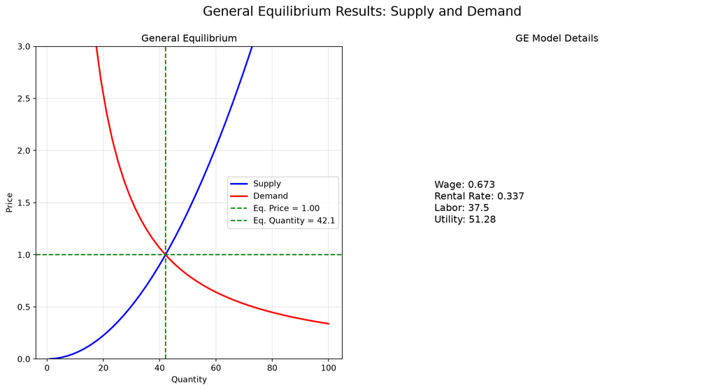